# Quick Prior-based Lung Segmentation from CT

Brian B. Avants et al.

8/16/2018

# Setup for problem

Use ANTsR and some prior knowledge about tissue statistics in CT.

```r
library( ANTsR )
centers = c(
  lung   = -821, # prior mean for lung
  label2 = -95,
  label3 = 67,
  label4 = 296,
  label5 = 863 )
```

# TCIA data

We employ example data from the TCIA public set.

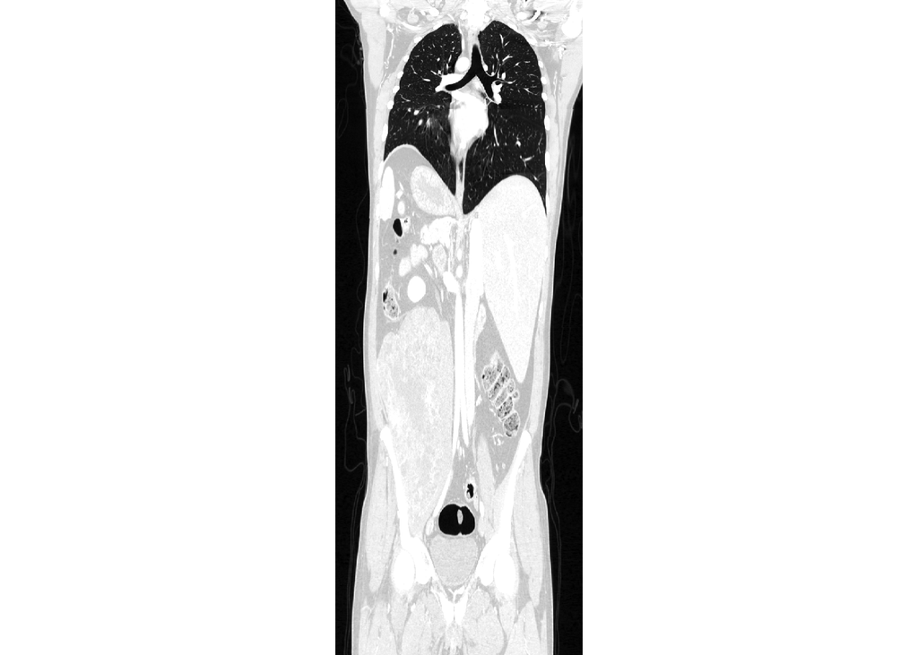

```
## [1] "../data/tcga_QQ_A5V2_chesttopelvis.nii.gz"
```

# Segmenting body from background

Take advantage of CT tissue quantification to extract body from background.

This approach may be fairly fragile (due to selection of erosion value and specific threshold values) but should be relatively easy to robustify and/or automate selection of best solution.

```r
######################################
segBody = thresholdImage( img, centers[1], Inf ) %>%
  morphology( "erode", 5 ) %>%
  iMath( "GetLargestComponent" ) %>%
  morphology( "close", 25 ) %>%
  iMath( "FillHoles" )
```

# Segmenting tissues and lung

Within the body mask, segment the tissues by k-means using the previously defined centers.

We choose the CT-based centers ( mean values ) to initialize the k-means consistently across subjects.

Results may vary some across runs but are overall consistent enough.

```r
invisible( gc() )
fastKMeans <- function(  img, mask, k, verbose = FALSE ) {
  km = kmeans( as.numeric( img[ mask == 1 ] ), centers = k  )
  if ( verbose )  print( km$centers )
  km = makeImage(  mask,  km[[1]] )
  return( km )
}
####
seg = fastKMeans( img, segBody, k = centers, verbose = TRUE )
```

```
##         [,1]
## 1 -821.61478
## 2  -91.79491
## 3   63.81277
## 4  288.55062
## 5  851.97265
```

```r
invisible( gc() )
#
```

# Label the lung

The first center selected above is generally the lung - we could get crazier later on but this makes the point. Need to see if this fails by running on larger datasets.

# Split left and right

We erode and label the components, throwing away small regions. This eventually gives us two big components which are probably the left and right lung labels.

```r
myval = 0
mye=0
# this assumes spacing is in millimeters
minLungSize = 0.5e6/prod( antsGetSpacing( lung ) ) # based on 0.5 Liter min lung volume
lungCrop = cropImage( lung, lung  )
while ( myval < 2 ) {
  mye = mye + 1
  temp = morphology( lungCrop, "erode", mye ) %>% labelClusters( minLungSize )
  myval = max( temp )
  invisible( gc() ) # force garbage collection to limit memory use
  print( myval )
  }
```

```
## [1] 1
## [1] 1
## [1] 1
## [1] 1
## [1] 2
```

```r
finalLungs = morphology( temp, "dilate", mye, type = "grayscale"  ) %>%
  decropImage( img )
antsImageWrite( finalLungs, paste0( "/tmp/lungs", basename( fn ) ))
antsImageWrite( vess, paste0( "/tmp/vess", basename( fn ) ))
```

The above process may also isolate the trachea - though i have not looked closely into this.

# Value of the result: We isolated the chest in the image

The labeled lung …

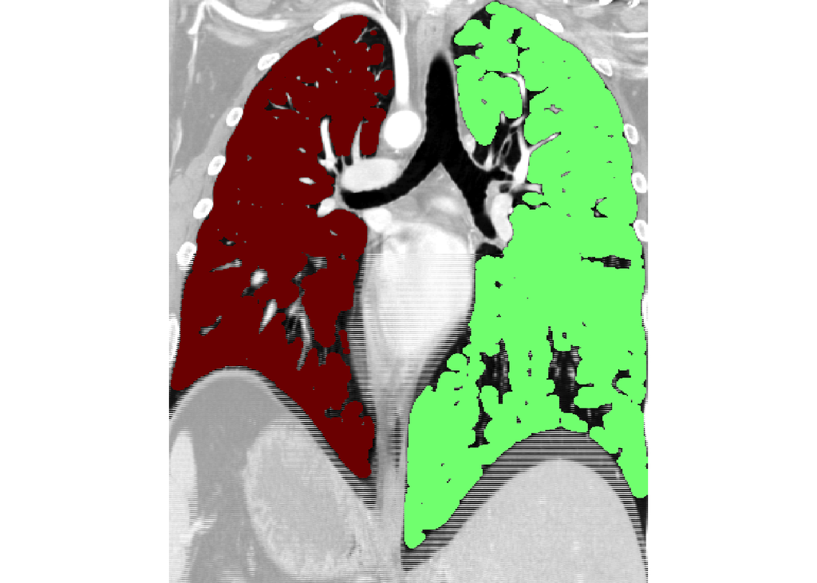

The labeled vasculature …

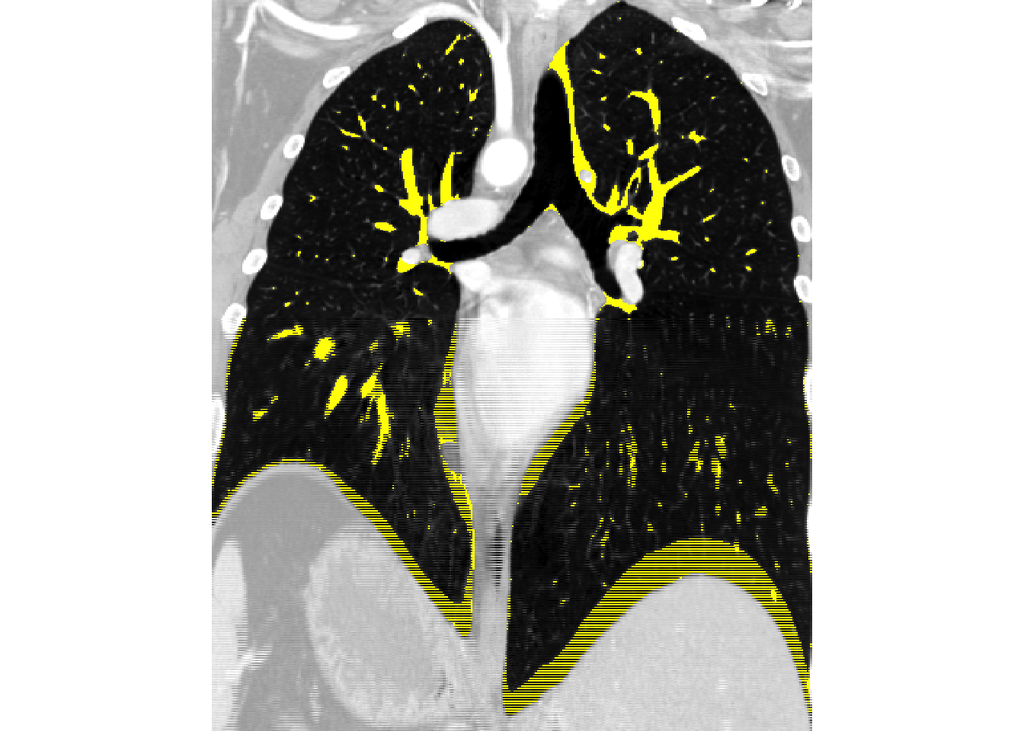

Something similar will likely work with X-ray, though perhaps not as well.

We can use the labeled lungs as initialization for cropping and orienting body CT images.

They also serve as a chest-oriented coordinate system where we know the heart is centered between left and right and that the liver is inferior to the right lung.

This is also useful for cropping, initializing registration and, ultimately, for segmentation.